# Introduction

The goal of this project is to predict, given an image related to wineyard context, if it presents some kind of distortion. The camera which is used should take some picture during the day to one particular subject and shows its transformation, in order to see the changements. There are some problems related. We noticed that some shots are not good. The tools that were used in this project are:

- Jupyter Notebook
- Scikit learn's libraries
- Python
- Matplotlib
- Plotly
- OpenCV
- PIL
- Numpy

We checked some tecniques in order to find a good classifier to accomplish our purpose.

```python
import numpy as np
import os
from sklearn.ensemble import IsolationForest
from sklearn.model_selection import train_test_split
import matplotlib.pyplot as plt
from os.path import join
import PIL
from PIL import Image, ImageOps
import cv2
from sklearn.model_selection import train_test_split, KFold, cross_val_score
from sklearn.naive_bayes import GaussianNB
import glob
```

## Introduction to Classification

From a Machine (or statistical) Learning point of view, our problem can be categorized like a **Supervised Problem** in the field of **Classification**.

**Classification** means the problem of identifying to which of a set of categories (sub-populations) a new observation belongs, on the basis of a training set of data containing observations (or instances) whose category membership is known. Examples are assigning a given email to the "spam" or "non-spam" class, and assigning a diagnosis to a given patient based on observed characteristics of the patient.

In the terminology of machine learning, classification is considered an instance of supervised learning, i.e., learning where a training set of correctly identified observations is available. The corresponding unsupervised procedure is known as clustering, and involves grouping data into categories based on some measure of inherent similarity or distance.

An algorithm that implements classification, especially in a concrete implementation, is known as a classifier. The term "classifier" sometimes also refers to the mathematical function, implemented by a classification algorithm, that maps input data to a category.

**Supervised learning** is the machine learning task of learning a function that maps an input to an output based on example input-output pairs. It infers a function from labeled training data consisting of a set of training examples. In supervised learning, each example is a pair consisting of an input object (typically a vector) and a desired output value (also called the supervisory signal).

A supervised learning algorithm analyzes the training data and produces an inferred function, which can be used for mapping new examples. An optimal scenario will allow for the algorithm to correctly determine the class labels for unseen instances. This requires the learning algorithm to generalize from the training data to unseen situations in a "reasonable" way.

## Problem Definition

All of the pictures were taken by 1110 Controller embedded camera and an ArduCam. These camera have the same problems. Our job is to build a classifier which can do Glitch identification and Noise identification, but which is more general as possible. During the accomplishment of the process we faced with some troubles.

Our material is based on two image datasets:

- *Photo_Villa*

  this dataset is characterized by an unbalanced amount of images which comprehend a majority of black-night and meaningless photos compared to the daytime and usefull photos. The unbalanceness of dataset was problematic becouse the classifier tends to overfit on the majority, and for Machine Learning purposes it is important that the dataset are quite balanced (as Normal distrubution) to avoid overfitting or underfitting. So some operations on dataset was required.

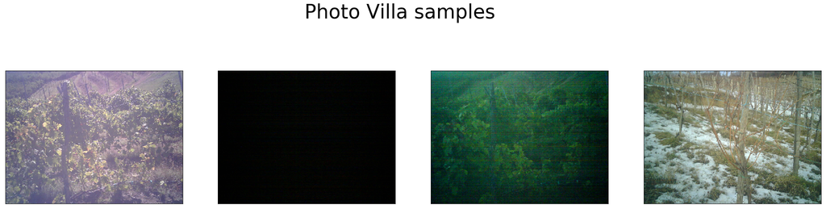

```python
fig, axs = plt.subplots(ncols=4, sharex=True, figsize=(30, 8))
fig.suptitle('Photo Villa samples', fontsize=40)
axs[0].get_xaxis().set_visible(False)
axs[0].get_yaxis().set_visible(False)
axs[0].imshow(Image.open("./photo_villa/CAM39_2017_09_12_11_37.jpg"))

axs[1].get_xaxis().set_visible(False)
axs[1].get_yaxis().set_visible(False)
axs[1].imshow(Image.open("./photo_villa/CAM39_2017_09_12_20_32.jpg"))

axs[2].get_xaxis().set_visible(False)
axs[2].get_yaxis().set_visible(False)
axs[2].imshow(Image.open("./photo_villa/CAM39_2017_09_19_06_45.jpg"))

axs[3].get_xaxis().set_visible(False)
axs[3].get_yaxis().set_visible(False)
axs[3].imshow(Image.open("./photo_villa/CAM39_2017_12_17_07_49.jpg"))
```

- *Photo_Ufficio*

  the set was composed of random photos taken from various contexts such as office, laboratories, and interns or some externs. In this case there are effectively some glitched photo, but the variance on the subjects makes the classification task deceptive in some ways. With this dataset, we do not perform data augmentation, that is trasformation by adding or changing some images in order to improve classifier's performances, but we work on the original one.

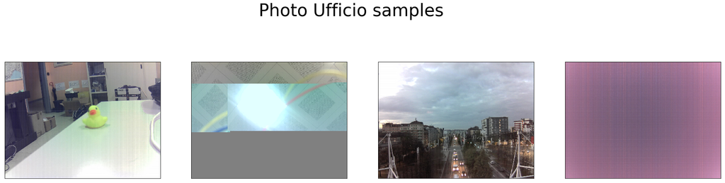

```python
fig, axs = plt.subplots(ncols=4, sharex=True, figsize=(30, 8))
fig.suptitle('Photo Ufficio samples', fontsize=40)
axs[0].get_xaxis().set_visible(False)
axs[0].get_yaxis().set_visible(False)
axs[0].imshow(Image.open("./image_dataset_2/1/2018-11-23_11.jpg"))

axs[1].get_xaxis().set_visible(False)
axs[1].get_yaxis().set_visible(False)
axs[1].imshow(Image.open("./image_dataset_2/0/2018-11-16_18.jpg"))

axs[2].get_xaxis().set_visible(False)
axs[2].get_yaxis().set_visible(False)
axs[2].imshow(Image.open("./image_dataset_2/1/2018-11-25_07.jpg"))

axs[3].get_xaxis().set_visible(False)
axs[3].get_yaxis().set_visible(False)
axs[3].imshow(Image.open("./image_dataset_2/0/2018-11-17_00.jpg"))
```

## Dataset Refinement

### Photo_Villa

The first dataset requires some operation on data, due to the absence of glitched samples in the image set, and the amount of black images. So we manually remove a certain number of black images to equilibrate the occurencies between nighttime and daytime photo. Then, our job was to make an hand-crafted separation between the two classes, where the class "1" represents the meaningfull images that we want to preserve, and class "0" describes photos without any sense and descartable. There was required to make some choice among the different kinds of photo in our dataset: we choose to consider as 0-class the elements with non-visible or partially visible subjects (such as full-dark photos or foggy photos), and as 1-class the elements that have some interesting information or visible subjects.

**Data Augmentation**: despite of the second dataset, the first one does not include distorted elements. This is a fundamental request that we have to solve before moving forward, so we decide to add some artificially-made glitched photos via https://snorpey.github.io/jpg-glitch/. This tool generate random glitched samples on uploaded images. In this way, we can obtain different form of glitch on the beginning image pushed from the photo_villa dataset. This help us to generate a balanced and more meaningfull dataset in order to make the classification task feasable and with sense. Furthermore, we increase the number of elements of the class "1" by extracting every frames of a timelapse video, downloaded from the IxemLab website.

### Photo_Ufficio

The second dataset was quite effective, but we decide to remove some dark photo to get a more general result for the classifier. The problems was related to photo loading of the openCV library: it requires to manage the different format types of images. But, despite all, it does not requires to many manipulation to start to work with it.

### Joining Photo_Villa and Photo_Ufficio

Finally we tried to join the two different datasets and to train a classifier on it. It was due to the fact that we want to make the problem as more general as possible, and to try to find some regularities among different natures of images. We just join the datasets and keeping the original labels, so it means that class 0 is made by the joining of the two class-0 groups, and the same for class-1.

## Data Models

### First approach: Image as collection of Pixels

Our first approach was the most common and traditional approach for image classification problems and it is based on considering an image as a collection of pixel, so one RGB image can be considered as a Matrix of triples: indeed each element of our matrix is composed by 3 values, one per color (R = red value, G = green value, B = blue value). So our matrix dimensions will be: **3 *number of pixels (so height* basis) * number of images** . This approach allow to represent image without information loss, becouse we just considered the whole (or, in our case, the resized) image, but it might leads to overfitting problem, due to the fact that there is no data generalization. Furthermore, considering the pictures in this way can provoke starvation or out-of-memory errors due to the huge dimension of bytes of the image set. So we tried to use another approach that can prevent this problems.

### Second approach: Image as Histograms

A color histogram of an image represents the distribution of the composition of colors in the image. It shows different types of colors appeared and the number of pixels in each type of the colors appeared. The formation of a color histogram is rather simple. From the definition above, we can simply count the number of pixels for each 256 scales in each of the 3 RGB channel, and plot them on 3 individual bar graphs.

Based on this approach, we have a way to go through the problem of data dimensionality (also defined, in ML context, as *Curse of dimensionality*) that could lead to computation complexity and time and memory waste. Moreover, it can define a good representation in terms of **generalization** of the image. As we already said, we can expect to be helped by data representation than are more general than the pixel-collection model.

The main drawback of histograms for classification is that the representation is dependent of the color of the object being studied, ignoring its shape and texture. Color histograms can potentially be identical for two images with different object content which happens to share color information. Conversely, without spatial or shape information, similar objects of different color may be indistinguishable based solely on color histogram comparisons. But this is not our case: we just use one subject (always the same), that change only gradually through the seasons and present only few differences in colors during the year, while glitched samples present random and unnatural tints. So we will problebly be able to detect its by using this representation.

## Approach and Classifiers Comparison

We will use as parameter of evaluation:

$Accuracy = \frac{TP + TN}{TP + FP + TN + FN}$

Accuracy, or Error Rate, describes the percentage of correct predictions made by the model. In short words, Accuracy = # correct / total predictions.

$Log Loss = -\sum_{c=1}^My_{o,c}\log(p_{o,c})$

where:

- N - number of observations
- M - number of possible class labels (dog, cat, fish)
- log - the natural logarithm
- y - a binary indicator (0 or 1) of whether class label c is the correct classification for observation o
- p - the model's predicted probability that observation o is of class c

we take the sum of log loss values for each class prediction in the observation. Logarithmic loss measures the performance of a classification model where the prediction input is a probability value between 0 and 1. The goal of our machine learning models is to minimize this value. A perfect model would have a log loss of 0. *Log loss increases as the predicted probability diverges from the actual label.*

$Training Time$

Time spent to *train* the model

$Test Time$

Time spent to *use* the model on testset

# First Approach

## Photo_villa:

```python
img_dir_0 = "./image_dataset/0"
img_dir_1 = "./image_dataset/1"
img_list_0 = [join(img_dir_0,filename) for filename in os.listdir(img_dir_0)]
img_list_1 = [join(img_dir_1,filename) for filename in os.listdir(img_dir_1)]

n_elem_0=len(os.listdir("./image_dataset/0"))
print("Number of elements/photos with 0 label:",n_elem_0)

n_elem_1=len(os.listdir("./image_dataset/1"))
print("Number of elements/photos with 1 label:",n_elem_1)

n_elem = n_elem_0 + n_elem_1
print("Number of elements/photos:",n_elem)
image_list=img_list_0+img_list_1
```

```
Number of elements/photos with 0 label: 228
Number of elements/photos with 1 label: 299
Number of elements/photos: 527
```

```python
w = 387
h = 290

image_matrix = np.zeros((n_elem,w*h*3), dtype=int)
for i,image in enumerate(image_list):
        taken = Image.open( image )
        taken.thumbnail([w,h],PIL.Image.ANTIALIAS)
        taken.resize([w,h],PIL.Image.ANTIALIAS)
        image_matrix[i] = np.asarray(taken).ravel()
```

Now we generate the labels to make possible to describe the pictures for classification: we already splitted images in "0" or "1" folds. So we just define a **labels vector** that collect a 1 in corrispondence of the good images (same position) and 0 otherwise. The dimension of *labels* is equal to the number of elements.

```python
y_0 = [0]*n_elem_0
y_1 = [1]*n_elem_1
labels = y_0 + y_1
print("Number of elements/photos:",len(labels))
```

```
Number of elements/photos: 527
```

Train_test_split divides the dataset in a set (Training) that allow to train the model, and a set (Test) that allow to test the model on datas that are not already known by the classifier itself.

```python
X_train, X_test, y_train, y_test = train_test_split(image_matrix,labels,test_size=0.3,random_state=37)
```

### Gaussian Naive Bayes Classifier

[figure not shown]

Here, there is the first machine learning approach we used:

Naive Bayes methods are a set of supervised learning algorithms based on applying Bayes’ theorem with the “naive” assumption of conditional independence between every pair of features given the value of the class variable. We can use Maximum A Posteriori (MAP) estimation to estimate; the former is then the relative frequency of class in the training set.

*Formulation:* $$\tilde{y} = \underset{y \in 1,2,3,4}{argmax} \ P(y | x_1, x_2,.., x_d) = \underset{y \in 1,2,3,4}{argmax} \ P(y) \prod_{i=1}^{d} P(x_i | y)$$

The different naive Bayes classifiers differ mainly by the assumptions they make regarding the distribution of $P(x_i | y)$

*GaussianNB* implements the Gaussian Naive Bayes algorithm for classification. The likelihood of the features is assumed to be **Gaussian**.

$$P(x_i \mid y) = \frac{1}{\sqrt{2\pi\sigma^2_y}} \exp\left(-\frac{(x_i - \mu_y)^2}{2\sigma^2_y}\right)$$

In short terms, it is a simple approach for Machine Learning that simply try to assign the label to the image that is *most probable*; Naive assumption allow us to consider each features **uncorrelated** each other, and Gaussian Naive Bayes use the gaussian distribution to approximize the probability distributions of the single features: it uses simple assumptions, but in most of the cases it works quite good.

```python
Classifiers=[]
Scores=[]
```

```python
import time
from sklearn import metrics

def score_model(clf,X,y,name):
    X_train, X_test, y_train, y_test = train_test_split(X,y,test_size = 0.3,random_state=25)
    start_tr = time.time()
    clf.fit(X_train,y_train)
    training_time=time.time()-start_tr
    start_te = time.time()
    predictions = clf.predict_proba(X)
    lloss=metrics.log_loss(y_true=y,y_pred=predictions,labels=[0,1])
    accuracy=clf.score(X_test,y_test)
    test_time = time.time()-start_te
    score_res = []
    score_res.append(("Name",name))
    score_res.append(("Accuracy",accuracy))
    #score_res.append(("Log Loss",lloss))
    score_res.append(("Training Time",training_time))
    score_res.append(("Test Time",test_time))
    print("Scores:")
    for name,result in score_res:
        print(name,"=",result)
    return score_res
```

```python
gnb = GaussianNB()
gnb.fit(X_train,y_train)
original_gnb_acc=gnb.score(X_test,y_test)
print("SCORE:",original_gnb_acc)

score_m = score_model(X=image_matrix,y=labels,clf=gnb,name="GNB - 1#Approach - PhotoVilla")
Scores.append(score_m)
```

```
SCORE: 0.9622641509433962
Scores:
Name = GNB - 1#Approach - PhotoVilla
Accuracy = 0.949685534591195
Training Time = 4.280512094497681
Test Time = 8.437445640563965
```

```python
def displayScores():
    for scores in Scores:
        print("                                  *****************")
        for name,result in scores:
            print("                                 ",name,"=",result)

    scores=[]
    for n in range(len(Scores)):
        scores.append(list(zip(*Scores[n]))[1])


    # make some plots

    indices = np.arange(len(scores))
    clf_names = [x[0] for x in scores]
    score = [x[1] for x in scores]
    #log_loss = [x[2] for x in scores]
    training_time = [x[2] for x in scores]
    test_time = [x[3] for x in scores]
    training_time = np.array(training_time) / np.max(training_time)
    test_time = np.array(test_time) / np.max(test_time)

    plt.figure(figsize=(15, 8))
    plt.title("Score")
    plt.barh(indices, score, .1, label="score", color='navy')
    #plt.barh(indices + .1, log_loss, .1, label="log_loss",
    #         color='g')
    plt.barh(indices + .1, training_time, .1, label="training time",
             color='c')
    plt.barh(indices + .2, test_time, .1, label="test time", color='darkorange')
    plt.yticks(())
    plt.grid()
    plt.legend(loc='best')
    plt.subplots_adjust(left=.25)
    plt.subplots_adjust(top=1.25)
    plt.subplots_adjust(bottom=.05)

    for i, c in zip(indices, clf_names):
        plt.text(-.4, i+.3, c)

    plt.show()



    print("Total time spent in classification:", np.sum(np.asarray(training_time))+np.sum(np.asarray(test_time)))
    print("Best accuracy:",np.max(score))
    #print("Best L.Loss:",np.min(log_loss))
    return
```

```
                                  *****************
                                  Name = GNB - 1#Approach - PhotoVilla
                                  Accuracy = 0.949685534591195
                                  Training Time = 4.280512094497681
                                  Test Time = 8.437445640563965
```

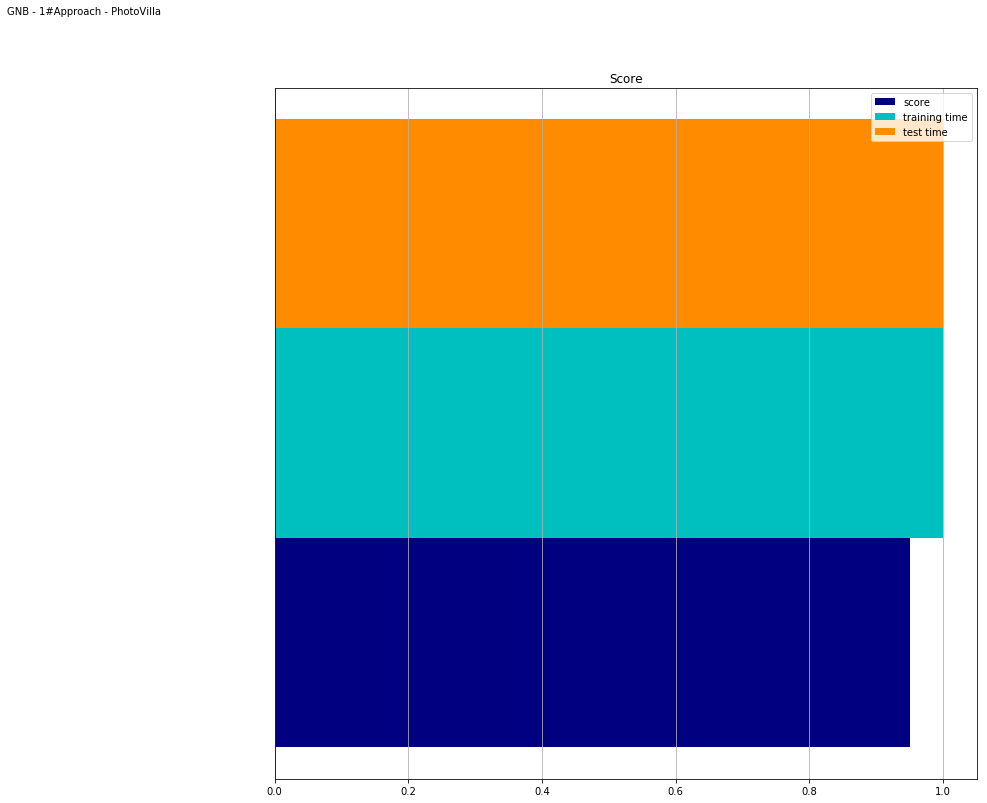

```
Total time spent in classification: 2.0
Best accuracy: 0.949685534591195
```

```python
displayScores()
```

**AUC (Area Under The Curve) ROC (Receiver Operating Characteristics) curve** is one of the most important evaluation metrics for checking any classification model’s performance. To define this, we define the following two metrics:

True positive rate (TPR): this is the same as the **recall**: $TPR = \frac{TP}{FN + TP}$

False positive rate (FPR): this corresponds to the proportion of negative data points that are mistakenly considered as positive, with respect to all negative data points: $FPR = \frac{FP}{TN + FP}$

ROC is a probability curve and AUC represents degree or measure of separability. It tells how much model is capable of distinguishing between classes. Higher the AUC, better the model is at predicting the correct class for each istance.

The ROC curve is plotted with TPR against the FPR where TPR is on y-axis and FPR is on the x-axis.

An excellent model has AUC near to the 1 which means it has good measure of separability. A poor model has AUC near to the 0 which means it has worst measure of separability. In fact it means it is reciprocating the result.

*The AUC, briefly, represent the amount of probability that a single instance with state of nature "1" will be well classified (as "1") against the probability that a single instance with state of nature "0" will be wrongly classified as "1", so it is a king of measurement of capability of discerness between class-members vs other instances.*

```python
from sklearn.metrics import roc_curve, auc
y_pred = gnb.predict_proba(X_test)[:, 1]
fpr, tpr, _ = roc_curve(y_test, y_pred)
roc_auc = auc(fpr, tpr)
```

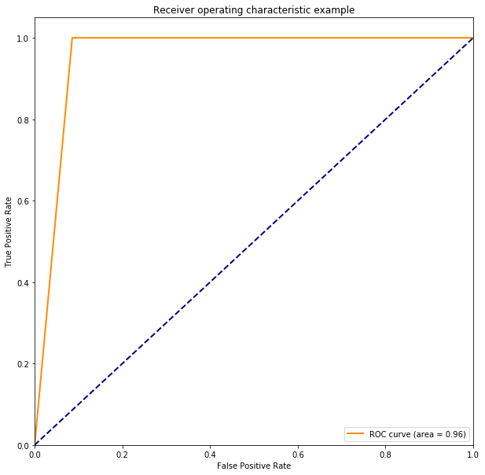

```python
plt.figure(figsize=(10,10))
lw = 2
plt.plot(fpr, tpr, color='darkorange',
         lw=lw, label='ROC curve (area = %0.2f)' % roc_auc)
plt.plot([0, 1], [0, 1], color='navy', lw=lw, linestyle='--')
plt.xlim([0.0, 1.0])
plt.ylim([0.0, 1.05])
plt.xlabel('False Positive Rate')
plt.ylabel('True Positive Rate')
plt.title('Receiver operating characteristic example')
plt.legend(loc="lower right")
plt.show()
```

### SVM Linear

[figure not shown]

The **support vector machine** is a generalization of a simple and intuitive classifier called the **maximal margin classifier**. Supposing that our data can be perfectly separated using a hyperplane, then there will in fact exist an infinite number of such hyperplanes. This is because a given separating hyperplane can usually be shifted a tiny bit up or down, or rotated, without coming into contact with any of the observations. The objective of the support vector machine algorithm is to find one hyperplane in an N-dimensional space(N — the number of features) that distinctly classifies the data points.

In order to construct a classifier based upon a separating hyperplane, we must have a reasonable way to decide which of the infinite possible separating hyperplanes to use. A natural choice is the **maximal margin hyperplane** which is the separating hyperplane that is *farthest from the training observations*. The maximal margin hyperplane is the separating hyperplane for which the margin is largest.

**Hyperplane**: $w_0+w_1x_1+w_2x_2+\cdots+w_nx_n=0$

**Optimization Problem for Hard Margin**: $$\max_{w_0...w_p}M \ subject \ to: \\ \ \sum_{j=1}^{p}w_j^2=1 \\ y_i(w_0 + w_1x_{i1} + ... + w_px_{pi}) \geq M \ \forall \ i=1..n $$

**Support vectors** are data points that are closer to the hyperplane and influence the position and orientation of the hyperplane. Using these support vectors, we maximize the margin of the classifier. Deleting the support vectors will change the position of the hyperplane. These are the points that help us build our SVM.

**Algorithm**: we need to estimate $β_j for j = 0, 1, ..., p$ and we do it as follows:

- put $ β_0=b $ and $β_k=w_k \ for \ k = 1, 2, ..., p$ where $b$ is the bias term and $w$ is the weights vector
- define $f(x)=b+w_1x_1+w_2x_2+...+w_px_p$
- initialize $b,w=0$
- REPEAT:
  - take $(x_i,y_i)$ from training data
  - if $y_if(x_i)≤0$ then $w=w+y_ix_i$ and $b=b+y_i$ (bias and weights are updated in case of misclassification)
  - UNTIL $y_if(x_i)>0$ for all training points (no more misclassifications)

In this algorithm the more $|y_if(x_i)|$ , the further is $x_i$ from the hyperplane and so the more confident we can be in assigning the $y_i$ label to it. Notice that, in order to apply this method points must be linearly separable, but, if they are, then there exists an infinite number of hyperplanes that can separate them. A natural approach is to choose the hyperplane that maximizes the distances (and makes it the same) between the hyperplane itself and the closest training points on the two sides so that we are more confident about the points dvision that has been executed. This alghoritm is kwown as Marginal Margin Classifier and it can be shown that it is the solution to the following optimization problem

Despite of everything, there are some reasons for which looking for a hyperplane that perfectly separates training points is not a so good idea:

- as usual, overfitting
- lack of robustness, since as a new training point comes we have to compute again the model and this could end up in a very different hyperplane even if training data are not linearly separable due to few points, we can not apply this algorithm. We now consider the so called Support Vector Classifier (or Soft Margin Classifier) starting from the previous one, but we give to it the possibility to do some mistakes as long as most of the training points are correctly classified (so the model will not change as frequently as for the Maximal Margin Classifier). In this case the optimization problem to solve is

**Optimization Problem for Soft Margin**: $$\max_{w_0...w_p,e_0...e_p} M \ subject \ to: \\ \ \sum_{j=1}^{p}w_j^2=1 \\ y_i(w_0 + w_1x_{i1} + ... + w_px_{pi})\geq M(1-e_i) \ \forall \ i=1..n \\ e_i \geq 0 \ \forall \ i=1..n \\ \sum_{i=1}^{n}e_i \geq C$$

Here ϵi are slack variables which allow training points that would be on the wrong side of the margin or of hyperplane to still comply with the second constraint of the optimization problem. For a given training point xj , if the corresponding slack variable is zero, then the point does not violated the margin, otherwise it does. C is a non-negative tuning parameters (we determine it by cross validation) which represents how much tolerant to points that violate the margin (or the hyperplane) we are: the more C , the more tolerant we are (so we let more points to violate the margin or the hyperplane or few of them but of a higher quantity) and the wider the margin. In this case the support vectors are both the points on the margin and the ones that violate it, so, again, the final model will depend only on these vectors even if the training datase is very huge and it will not change for new training points far from the margin (the model is more robust).

In addition to performing linear classification, SVMs can efficiently perform a non-linear classification using what is called the kernel trick, implicitly mapping their inputs into high-dimensional feature spaces. Kernel methods, or kernel trick, owe their name to the use of kernel functions, which enable them to operate in a high-dimensional, implicit feature space without ever computing the coordinates of the data in that space, but rather by simply computing the inner products between the images of all pairs of data in the feature space. This operation is often computationally cheaper than the explicit computation of the coordinates. It allows to transform the linear hyperplane to fit an un-linear problem.

```python
from sklearn import svm

svm = svm.SVC(kernel="linear",probability=True)

score_m = score_model(X=image_matrix,y=labels,clf=svm,name="Linear SVM - 1#Approach - PhotoVilla")
Scores.append(score_m)
```

```
Scores:
Name = Linear SVM - 1#Approach - PhotoVilla
Accuracy = 0.9433962264150944
Training Time = 169.62561988830566
Test Time = 53.58669948577881
```

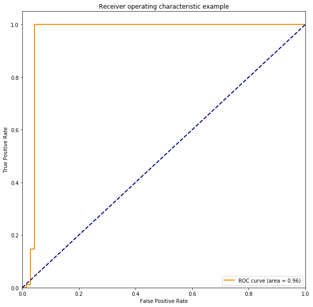

```python
y_pred = svm.predict_proba(X_test)[:, 1]
fpr, tpr, _ = roc_curve(y_test, y_pred)
roc_auc = auc(fpr, tpr)

plt.figure(figsize=(10,10))
lw = 2
plt.plot(fpr, tpr, color='darkorange',
         lw=lw, label='ROC curve (area = %0.2f)' % roc_auc)
plt.plot([0, 1], [0, 1], color='navy', lw=lw, linestyle='--')
plt.xlim([0.0, 1.0])
plt.ylim([0.0, 1.05])
plt.xlabel('False Positive Rate')
plt.ylabel('True Positive Rate')
plt.title('Receiver operating characteristic example')
plt.legend(loc="lower right")
plt.show()
```

```
                                  *****************
                                  Name = GNB - 1#Approach - PhotoVilla
                                  Accuracy = 0.949685534591195
                                  Training Time = 4.280512094497681
                                  Test Time = 8.437445640563965
                                  *****************
                                  Name = Linear SVM - 1#Approach - PhotoVilla
                                  Accuracy = 0.9433962264150944
                                  Training Time = 169.62561988830566
                                  Test Time = 53.58669948577881
```

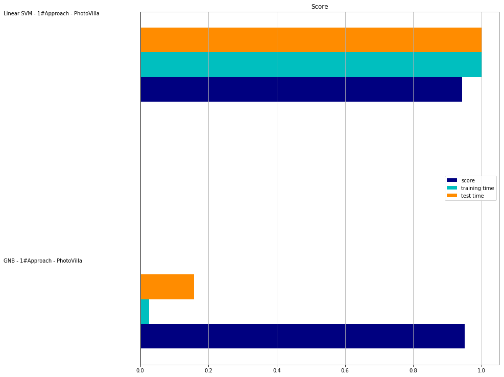

```
Total time spent in classification: 2.1826891583432886
Best accuracy: 0.949685534591195
```

```python
displayScores()
```

## Photo_ufficio

Now we just do the same operations for PhotoUfficio

```python
img_dir_0 = "./image_dataset_2/0"
img_dir_1 = "./image_dataset_2/1"
img_list_0 = [join(img_dir_0,filename) for filename in os.listdir(img_dir_0)]
img_list_1 = [join(img_dir_1,filename) for filename in os.listdir(img_dir_1)]

n_elem_0=len(os.listdir("./image_dataset_2/0"))
print("Number of elements/photos with 0 label:",n_elem_0)

n_elem_1=len(os.listdir("./image_dataset_2/1"))
print("Number of elements/photos with 1 label:",n_elem_1)

n_elem = n_elem_0 + n_elem_1
print("Number of elements/photos:",n_elem)
image_list=img_list_0+img_list_1
```

```
Number of elements/photos with 0 label: 95
Number of elements/photos with 1 label: 233
Number of elements/photos: 328
```

Here we resize and transform data to be collected as a numpy matrix. **Numpy** is the numeric and mathematical library that has an huge diffusion in python. It is the only way to collect vectors and matrices. As said, our matrix will have dimension of: **rows** = _n*elem* **columns** = *300x400x3* = 360000 pixels, represented in a *flatten* representation.

```python
from PIL import ImageFile
ImageFile.LOAD_TRUNCATED_IMAGES = True

size = 400,300
image_matrix = np.zeros((n_elem,300*400*3), dtype=int)
for i,image in enumerate(image_list):
    taken = Image.open( image )
    taken.thumbnail(size,Image.ANTIALIAS)
    image_matrix[i] = np.asarray(taken).ravel()
```

Now we generate the labels to make possible to describe the pictures for classification: we already splitted images in "0" or "1" folds. So we just define a **labels vector** that collect a 1 in corrispondence of the good images (same position) and 0 otherwise. The dimension of *labels* is equal to the number of elements.

```python
y_0 = [0]*n_elem_0
y_1 = [1]*n_elem_1
labels = y_0 + y_1
print(labels)
```

```
[0, 0, 0, 0, 0, 0, 0, 0, 0, 0, 0, 0, 0, 0, 0, 0, 0, 0, 0, 0, 0, 0, 0, 0, 0, 0, 0, 0, 0, 0, 0, 0, 0, 0, 0, 0, 0, 0, 0, 0, 0, 0, 0, 0, 0, 0, 0, 0, 0, 0, 0, 0, 0, 0, 0, 0, 0, 0, 0, 0, 0, 0, 0, 0, 0, 0, 0, 0, 0, 0, 0, 0, 0, 0, 0, 0, 0, 0, 0, 0, 0, 0, 0, 0, 0, 0, 0, 0, 0, 0, 0, 0, 0, 0, 0, 1, 1, 1, 1, 1,…
```

Train_test_split divides the dataset in a set (Training) that allow to train the model, and a set (Test) that allow to test the model on datas that are not already known by the classifier itself.

```python
X_train, X_test, y_train, y_test = train_test_split(image_matrix,labels,test_size=0.3,random_state=37)
```

### Gaussian Naive Bayes Classifier

```python
import time
from sklearn import metrics

def score_model(clf,X,y,name):
    X_train, X_test, y_train, y_test = train_test_split(X,y,test_size = 0.3,random_state=25)
    start_tr = time.time()
    clf.fit(X_train,y_train)
    training_time=time.time()-start_tr
    start_te = time.time()
    predictions = clf.predict_proba(X)
    lloss=metrics.log_loss(y_true=y,y_pred=predictions,labels=[0,1])
    accuracy=clf.score(X_test,y_test)
    test_time = time.time()-start_te
    score_res = []
    score_res.append(("Name",name))
    score_res.append(("Accuracy",accuracy))
    score_res.append(("Log Loss",lloss))
    score_res.append(("Training Time",training_time))
    score_res.append(("Test Time",test_time))
    print("Scores:")
    for name,result in score_res:
        print(name,"=",result)
    return score_res
```

```python
gnb = GaussianNB()
gnb.fit(X_train,y_train)
original_gnb_acc=gnb.score(X_test,y_test)
print("SCORE:",original_gnb_acc)

score_m = score_model(X=image_matrix,y=labels,clf=gnb,name="GNB - 1#Approach - PhotoUfficio")
Scores.append(score_m)
```

```
SCORE: 0.7676767676767676
Scores:
Name = GNB - 1#Approach - PhotoUfficio
Accuracy = 0.8080808080808081
Log Loss = 6.318068852727564
Training Time = 2.920057773590088
Test Time = 5.805481910705566
```

```
                                  *****************
                                  Name = GNB - 1#Approach - PhotoVilla
                                  Accuracy = 0.949685534591195
                                  Training Time = 4.280512094497681
                                  Test Time = 8.437445640563965
                                  *****************
                                  Name = Linear SVM - 1#Approach - PhotoVilla
                                  Accuracy = 0.9433962264150944
                                  Training Time = 169.62561988830566
                                  Test Time = 53.58669948577881
                                  *****************
                                  Name = GNB - 1#Approach - PhotoUfficio
                                  Accuracy = 0.8080808080808081
                                  Log Loss = 6.318068852727564
                                  Training Time = 2.920057773590088
                                  Test Time = 5.805481910705566
```

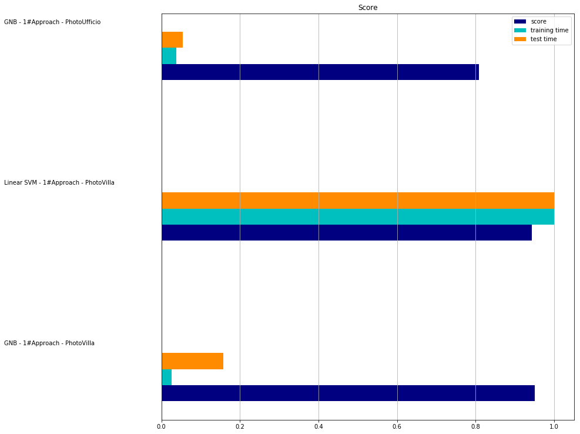

```
Total time spent in classification: 2.2744285079447337
Best accuracy: 0.949685534591195
```

```python
displayScores()
```

```python
from sklearn.metrics import roc_curve, auc
y_pred = gnb.predict_proba(X_test)[:, 1]
fpr, tpr, _ = roc_curve(y_test, y_pred)
roc_auc = auc(fpr, tpr)
```

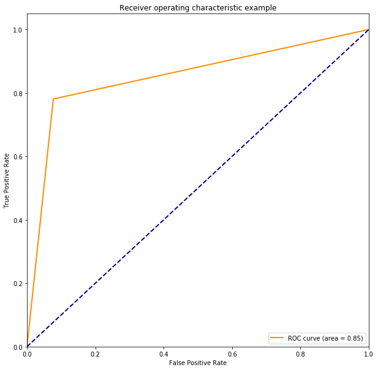

```python
plt.figure(figsize=(10,10))
lw = 2
plt.plot(fpr, tpr, color='darkorange',
         lw=lw, label='ROC curve (area = %0.2f)' % roc_auc)
plt.plot([0, 1], [0, 1], color='navy', lw=lw, linestyle='--')
plt.xlim([0.0, 1.0])
plt.ylim([0.0, 1.05])
plt.xlabel('False Positive Rate')
plt.ylabel('True Positive Rate')
plt.title('Receiver operating characteristic example')
plt.legend(loc="lower right")
plt.show()
```

### SVM Linear

```
Scores:
Name = Linear SVM - 1#Approach - PhotoUfficio
Accuracy = 0.9090909090909091
Log Loss = 0.13265681483572453
Training Time = 89.46020197868347
Test Time = 31.01409602165222
                                  *****************
                                  Name = GNB - 1#Approach - PhotoVilla
                                  Accuracy = 0.949685534591195
                                  Training Time = 4.280512094497681
                                  Test Time = 8.437445640563965
                                  *****************
                                  Name = Linear SVM - 1#Approach - PhotoVilla
                                  Accuracy = 0.9433962264150944
                                  Training Time = 169.62561988830566
                                  Test Time = 53.58669948577881
                                  *****************
                                  Name = GNB - 1#Approach - PhotoUfficio
                                  Accuracy = 0.8080808080808081
                                  Log Loss = 6.318068852727564
                                  Training Time = 2.920057773590088
                                  Test Time = 5.805481910705566
                                  *****************
                                  Name = Linear SVM - 1#Approach - PhotoUfficio
                                  Accuracy = 0.9090909090909091
                                  Log Loss = 0.13265681483572453
                                  Training Time = 89.46020197868347
                                  Test Time = 31.01409602165222
```

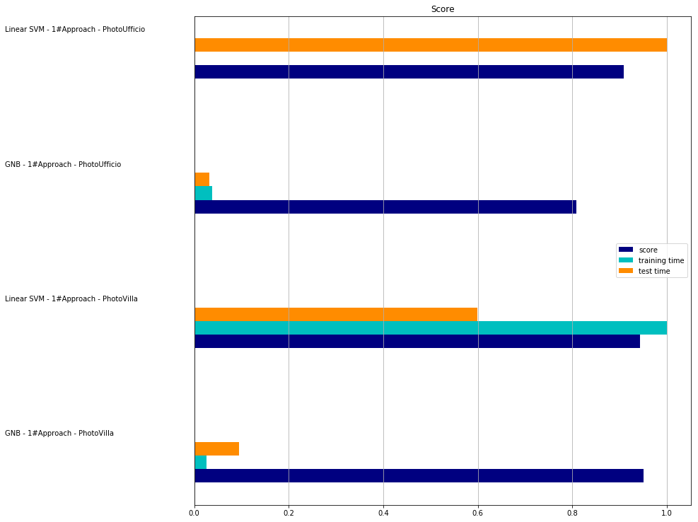

```
Total time spent in classification: 2.78922061424718
Best accuracy: 0.949685534591195
```

```python
from sklearn import svm

svm = svm.SVC(kernel="linear",probability=True)

score_m = score_model(X=image_matrix,y=labels,clf=svm,name="Linear SVM - 1#Approach - PhotoUfficio")
Scores.append(score_m)

displayScores()
```

# Second Approach

The second approach is based on the usage of histogram representations instead of the whole pixels of the image. Here we will replicate the experiments already explained in our first part and we will display all the results.

## Photo_villa:

```python
img_dir_0 = "./image_dataset/0"
img_dir_1 = "./image_dataset/1"
img_list_0 = [join(img_dir_0,filename) for filename in os.listdir(img_dir_0)]
img_list_1 = [join(img_dir_1,filename) for filename in os.listdir(img_dir_1)]

n_elem_0=len(os.listdir("./image_dataset/0"))
print("Number of elements/photos with 0 label:",n_elem_0)

n_elem_1=len(os.listdir("./image_dataset/1"))
print("Number of elements/photos with 1 label:",n_elem_1)

n_elem = n_elem_0 + n_elem_1
print("Number of elements/photos:",n_elem)
image_list=img_list_0+img_list_1
```

```
Number of elements/photos with 0 label: 228
Number of elements/photos with 1 label: 299
Number of elements/photos: 527
```

```python
# Extract histogram from one image

def extract_hist(img):
    color = ('b','g','r')
    histogram = np.empty([3,256])
    for channel,col in enumerate(color):
        histr = cv2.calcHist([np.asarray(img)],[channel],None,[256],[0,256])
        histogram[channel] = np.transpose(histr)
    return histogram.ravel()
```

```python
import cv2
image_matrix = np.zeros((len(img_list_0) + len(img_list_1),768), dtype=int)
labels = []
i = 0

for image in img_list_0:
    image_matrix[i] = extract_hist(Image.open( image ))
    labels.append(0)
    i+=1

for image in img_list_1:
    image_matrix[i] = extract_hist(Image.open( image ))
    labels.append(1)
    i+=1

print(labels)
```

```
[0, 0, 0, 0, 0, 0, 0, 0, 0, 0, 0, 0, 0, 0, 0, 0, 0, 0, 0, 0, 0, 0, 0, 0, 0, 0, 0, 0, 0, 0, 0, 0, 0, 0, 0, 0, 0, 0, 0, 0, 0, 0, 0, 0, 0, 0, 0, 0, 0, 0, 0, 0, 0, 0, 0, 0, 0, 0, 0, 0, 0, 0, 0, 0, 0, 0, 0, 0, 0, 0, 0, 0, 0, 0, 0, 0, 0, 0, 0, 0, 0, 0, 0, 0, 0, 0, 0, 0, 0, 0, 0, 0, 0, 0, 0, 0, 0, 0, 0, 0,…
```

Now we generate the labels to make possible to describe the pictures for classification: we already splitted images in "0" or "1" folds. So we just define a **labels vector** that collect a 1 in corrispondence of the good images (same position) and 0 otherwise. The dimension of *labels* is equal to the number of elements.

Train_test_split divides the dataset in a set (Training) that allow to train the model, and a set (Test) that allow to test the model on datas that are not already known by the classifier itself.

```python
X_train, X_test, y_train, y_test = train_test_split(image_matrix,labels,test_size=0.3,random_state=37)
```

### Gaussian Naive Bayes Classifier

```python
import time
from sklearn import metrics

def score_model(clf,X,y,name):
    X_train, X_test, y_train, y_test = train_test_split(X,y,test_size = 0.3,random_state=25)
    start_tr = time.time()
    clf.fit(X_train,y_train)
    training_time=time.time()-start_tr
    start_te = time.time()
    predictions = clf.predict_proba(X)
    lloss=metrics.log_loss(y_true=y,y_pred=predictions,labels=[0,1])
    accuracy=clf.score(X_test,y_test)
    test_time = time.time()-start_te
    score_res = []
    score_res.append(("Name",name))
    score_res.append(("Accuracy",accuracy))
    score_res.append(("Log Loss",lloss))
    score_res.append(("Training Time",training_time))
    score_res.append(("Test Time",test_time))
    print("Scores:")
    for name,result in score_res:
        print(name,"=",result)
    return score_res
```

```python
gnb = GaussianNB()
gnb.fit(X_train,y_train)
original_gnb_acc=gnb.score(X_test,y_test)
print("SCORE:",original_gnb_acc)

score_m = score_model(X=image_matrix,y=labels,clf=gnb,name="GNB - 2#Approach - PhotoVilla")
Scores.append(score_m)
```

```
SCORE: 0.9622641509433962
Scores:
Name = GNB - 2#Approach - PhotoVilla
Accuracy = 0.949685534591195
Log Loss = 1.0486156021225261
Training Time = 0.00997304916381836
Test Time = 0.021976232528686523
```

```
                                  *****************
                                  Name = GNB - 1#Approach - PhotoVilla
                                  Accuracy = 0.949685534591195
                                  Training Time = 4.280512094497681
                                  Test Time = 8.437445640563965
                                  *****************
                                  Name = Linear SVM - 1#Approach - PhotoVilla
                                  Accuracy = 0.9433962264150944
                                  Training Time = 169.62561988830566
                                  Test Time = 53.58669948577881
                                  *****************
                                  Name = GNB - 1#Approach - PhotoUfficio
                                  Accuracy = 0.8080808080808081
                                  Log Loss = 6.318068852727564
                                  Training Time = 2.920057773590088
                                  Test Time = 5.805481910705566
                                  *****************
                                  Name = Linear SVM - 1#Approach - PhotoUfficio
                                  Accuracy = 0.9090909090909091
                                  Log Loss = 0.13265681483572453
                                  Training Time = 89.46020197868347
                                  Test Time = 31.01409602165222
                                  *****************
                                  Name = GNB - 2#Approach - PhotoVilla
                                  Accuracy = 0.949685534591195
                                  Log Loss = 1.0486156021225261
                                  Training Time = 0.00997304916381836
                                  Test Time = 0.021976232528686523
```

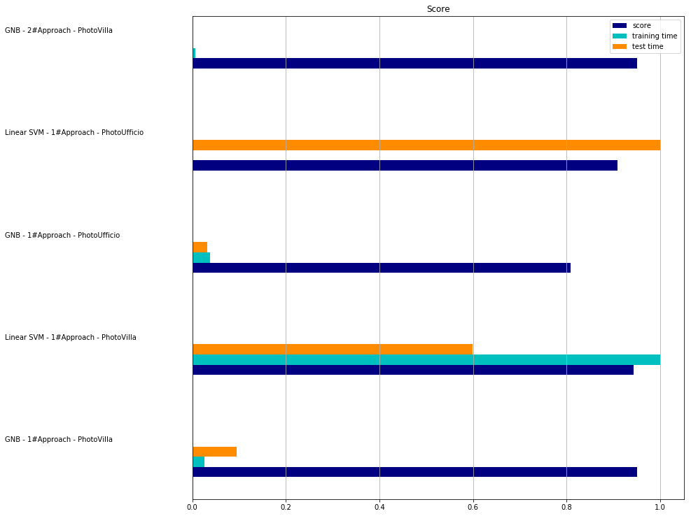

```
Total time spent in classification: 2.7955140357004935
Best accuracy: 0.949685534591195
```

```python
displayScores()
```

**AUC (Area Under The Curve) ROC (Receiver Operating Characteristics) curve** is one of the most important evaluation metrics for checking any classification model’s performance. To define this, we define the following two metrics:

True positive rate (TPR): this is the same as the **recall**: $TPR = \frac{TP}{FN + TP}$

False positive rate (FPR): this corresponds to the proportion of negative data points that are mistakenly considered as positive, with respect to all negative data points: $FPR = \frac{FP}{TN + FP}$

ROC is a probability curve and AUC represents degree or measure of separability. It tells how much model is capable of distinguishing between classes. Higher the AUC, better the model is at predicting the correct class for each istance.

The ROC curve is plotted with TPR against the FPR where TPR is on y-axis and FPR is on the x-axis.

An excellent model has AUC near to the 1 which means it has good measure of separability. A poor model has AUC near to the 0 which means it has worst measure of separability. In fact it means it is reciprocating the result.

*The AUC, briefly, represent the amount of probability that a single instance with state of nature "1" will be well classified (as "1") against the probability that a single instance with state of nature "0" will be wrongly classified as "1", so it is a king of measurement of capability of discerness between class-members vs other instances.*

```python
from sklearn.metrics import roc_curve, auc
y_pred = gnb.predict_proba(X_test)[:, 1]
fpr, tpr, _ = roc_curve(y_test, y_pred)
roc_auc = auc(fpr, tpr)
```

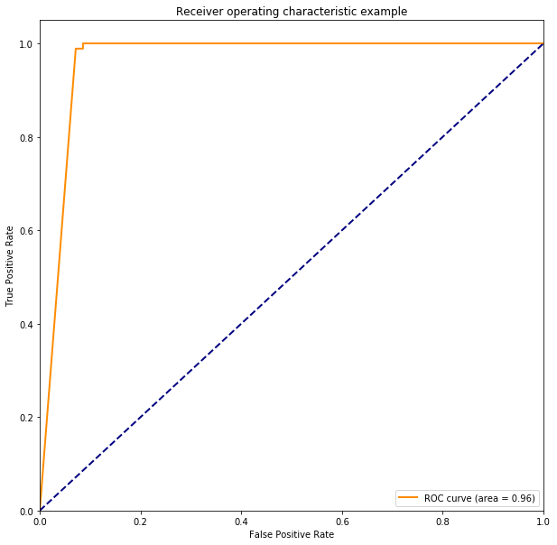

```python
plt.figure(figsize=(10,10))
lw = 2
plt.plot(fpr, tpr, color='darkorange',
         lw=lw, label='ROC curve (area = %0.2f)' % roc_auc)
plt.plot([0, 1], [0, 1], color='navy', lw=lw, linestyle='--')
plt.xlim([0.0, 1.0])
plt.ylim([0.0, 1.05])
plt.xlabel('False Positive Rate')
plt.ylabel('True Positive Rate')
plt.title('Receiver operating characteristic example')
plt.legend(loc="lower right")
plt.show()
```

### SVM Linear

```
Scores:
Name = Linear SVM - 2#Approach - PhotoVilla
Accuracy = 0.9811320754716981
Log Loss = 0.027058498046843543
Training Time = 0.06582331657409668
Test Time = 0.020943880081176758
                                  *****************
                                  Name = GNB - 1#Approach - PhotoVilla
                                  Accuracy = 0.949685534591195
                                  Training Time = 4.280512094497681
                                  Test Time = 8.437445640563965
                                  *****************
                                  Name = Linear SVM - 1#Approach - PhotoVilla
                                  Accuracy = 0.9433962264150944
                                  Training Time = 169.62561988830566
                                  Test Time = 53.58669948577881
                                  *****************
                                  Name = GNB - 1#Approach - PhotoUfficio
                                  Accuracy = 0.8080808080808081
                                  Log Loss = 6.318068852727564
                                  Training Time = 2.920057773590088
                                  Test Time = 5.805481910705566
                                  *****************
                                  Name = Linear SVM - 1#Approach - PhotoUfficio
                                  Accuracy = 0.9090909090909091
                                  Log Loss = 0.13265681483572453
                                  Training Time = 89.46020197868347
                                  Test Time = 31.01409602165222
                                  *****************
                                  Name = GNB - 2#Approach - PhotoVilla
                                  Accuracy = 0.949685534591195
                                  Log Loss = 1.0486156021225261
                                  Training Time = 0.00997304916381836
                                  Test Time = 0.021976232528686523
                                  *****************
                                  Name = Linear SVM - 2#Approach - PhotoVilla
                                  Accuracy = 0.9811320754716981
                                  Log Loss = 0.027058498046843543
                                  Training Time = 0.06582331657409668
                                  Test Time = 0.020943880081176758
```

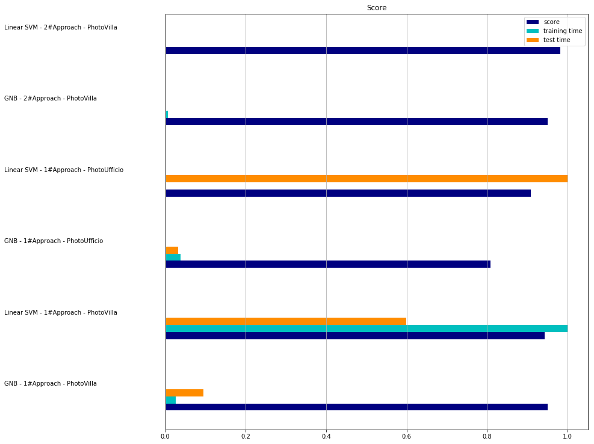

```
Total time spent in classification: 2.7964093378666943
Best accuracy: 0.9811320754716981
```

```python
from sklearn import svm

svm = svm.SVC(kernel="linear",probability=True)

score_m = score_model(X=image_matrix,y=labels,clf=svm,name="Linear SVM - 2#Approach - PhotoVilla")
Scores.append(score_m)

displayScores()
```

## Photo_ufficio

Now we just do the same operations for PhotoUfficio

```python
img_dir_0 = "./image_dataset_2/0"
img_dir_1 = "./image_dataset_2/1"
img_list_0 = [join(img_dir_0,filename) for filename in os.listdir(img_dir_0)]
img_list_1 = [join(img_dir_1,filename) for filename in os.listdir(img_dir_1)]

n_elem_0=len(os.listdir("./image_dataset_2/0"))
print("Number of elements/photos with 0 label:",n_elem_0)

n_elem_1=len(os.listdir("./image_dataset_2/1"))
print("Number of elements/photos with 1 label:",n_elem_1)

n_elem = n_elem_0 + n_elem_1
print("Number of elements/photos:",n_elem)
image_list=img_list_0+img_list_1
```

```
Number of elements/photos with 0 label: 95
Number of elements/photos with 1 label: 233
Number of elements/photos: 328
```

```python
import cv2
image_matrix = np.zeros((len(img_list_0) + len(img_list_1),768), dtype=int)
labels = []
i = 0

for image in img_list_0:
    image_matrix[i] = extract_hist(Image.open( image ))
    labels.append(0)
    i+=1

for image in img_list_1:
    image_matrix[i] = extract_hist(Image.open( image ))
    labels.append(1)
    i+=1

print(labels)
```

```
[0, 0, 0, 0, 0, 0, 0, 0, 0, 0, 0, 0, 0, 0, 0, 0, 0, 0, 0, 0, 0, 0, 0, 0, 0, 0, 0, 0, 0, 0, 0, 0, 0, 0, 0, 0, 0, 0, 0, 0, 0, 0, 0, 0, 0, 0, 0, 0, 0, 0, 0, 0, 0, 0, 0, 0, 0, 0, 0, 0, 0, 0, 0, 0, 0, 0, 0, 0, 0, 0, 0, 0, 0, 0, 0, 0, 0, 0, 0, 0, 0, 0, 0, 0, 0, 0, 0, 0, 0, 0, 0, 0, 0, 0, 0, 1, 1, 1, 1, 1,…
```

Now we generate the labels to make possible to describe the pictures for classification: we already splitted images in "0" or "1" folds. So we just define a **labels vector** that collect a 1 in corrispondence of the good images (same position) and 0 otherwise. The dimension of *labels* is equal to the number of elements.

Train_test_split divides the dataset in a set (Training) that allow to train the model, and a set (Test) that allow to test the model on datas that are not already known by the classifier itself.

```python
X_train, X_test, y_train, y_test = train_test_split(image_matrix,labels,test_size=0.3,random_state=37)
```

### Gaussian Naive Bayes Classifier

```python
import time
from sklearn import metrics

def score_model(clf,X,y,name):
    X_train, X_test, y_train, y_test = train_test_split(X,y,test_size = 0.3,random_state=25)
    start_tr = time.time()
    clf.fit(X_train,y_train)
    training_time=time.time()-start_tr
    start_te = time.time()
    predictions = clf.predict_proba(X)
    lloss=metrics.log_loss(y_true=y,y_pred=predictions,labels=[0,1])
    accuracy=clf.score(X_test,y_test)
    test_time = time.time()-start_te
    score_res = []
    score_res.append(("Name",name))
    score_res.append(("Accuracy",accuracy))
    score_res.append(("Log Loss",lloss))
    score_res.append(("Training Time",training_time))
    score_res.append(("Test Time",test_time))
    print("Scores:")
    for name,result in score_res:
        print(name,"=",result)
    return score_res
```

```python
gnb = GaussianNB()
gnb.fit(X_train,y_train)
original_gnb_acc=gnb.score(X_test,y_test)
print("SCORE:",original_gnb_acc)

score_m = score_model(X=image_matrix,y=labels,clf=gnb,name="GNB - 2#Approach - PhotoUfficio")
Scores.append(score_m)
```

```
SCORE: 0.9494949494949495
Scores:
Name = GNB - 2#Approach - PhotoUfficio
Accuracy = 0.7676767676767676
Log Loss = 7.287524456993407
Training Time = 0.003988504409790039
Test Time = 0.009974479675292969
```

```
                                  *****************
                                  Name = GNB - 1#Approach - PhotoVilla
                                  Accuracy = 0.949685534591195
                                  Training Time = 4.280512094497681
                                  Test Time = 8.437445640563965
                                  *****************
                                  Name = Linear SVM - 1#Approach - PhotoVilla
                                  Accuracy = 0.9433962264150944
                                  Training Time = 169.62561988830566
                                  Test Time = 53.58669948577881
                                  *****************
                                  Name = GNB - 1#Approach - PhotoUfficio
                                  Accuracy = 0.8080808080808081
                                  Log Loss = 6.318068852727564
                                  Training Time = 2.920057773590088
                                  Test Time = 5.805481910705566
                                  *****************
                                  Name = Linear SVM - 1#Approach - PhotoUfficio
                                  Accuracy = 0.9090909090909091
                                  Log Loss = 0.13265681483572453
                                  Training Time = 89.46020197868347
                                  Test Time = 31.01409602165222
                                  *****************
                                  Name = GNB - 2#Approach - PhotoVilla
                                  Accuracy = 0.949685534591195
                                  Log Loss = 1.0486156021225261
                                  Training Time = 0.00997304916381836
                                  Test Time = 0.021976232528686523
                                  *****************
                                  Name = Linear SVM - 2#Approach - PhotoVilla
                                  Accuracy = 0.9811320754716981
                                  Log Loss = 0.027058498046843543
                                  Training Time = 0.06582331657409668
                                  Test Time = 0.020943880081176758
                                  *****************
                                  Name = GNB - 2#Approach - PhotoUfficio
                                  Accuracy = 0.7676767676767676
                                  Log Loss = 7.287524456993407
                                  Training Time = 0.003988504409790039
                                  Test Time = 0.009974479675292969
```

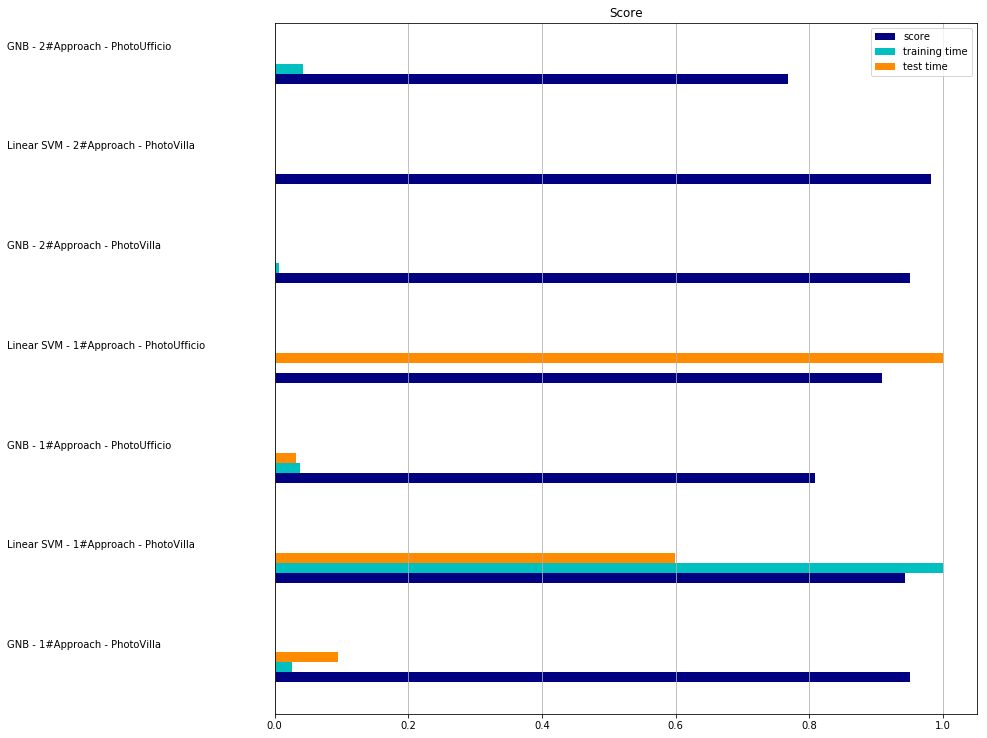

```
Total time spent in classification: 2.8394163262617567
Best accuracy: 0.9811320754716981
```

```python
displayScores()
```

```python
from sklearn.metrics import roc_curve, auc
y_pred = gnb.predict_proba(X_test)[:, 1]
fpr, tpr, _ = roc_curve(y_test, y_pred)
roc_auc = auc(fpr, tpr)
```

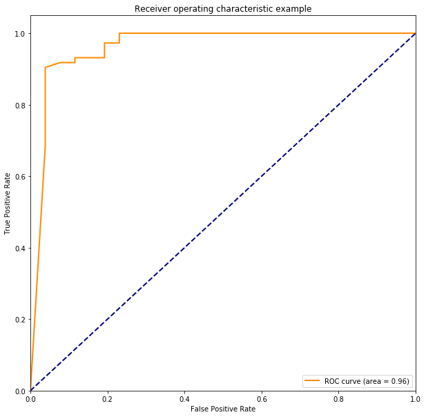

```python
plt.figure(figsize=(10,10))
lw = 2
plt.plot(fpr, tpr, color='darkorange',
         lw=lw, label='ROC curve (area = %0.2f)' % roc_auc)
plt.plot([0, 1], [0, 1], color='navy', lw=lw, linestyle='--')
plt.xlim([0.0, 1.0])
plt.ylim([0.0, 1.05])
plt.xlabel('False Positive Rate')
plt.ylabel('True Positive Rate')
plt.title('Receiver operating characteristic example')
plt.legend(loc="lower right")
plt.show()
```

### SVM Linear

```python
from sklearn import svm

svm = svm.SVC(kernel="linear",probability=True)

score_m = score_model(X=image_matrix,y=labels,clf=svm,name="Linear SVM - 2#Approach - PhotoUfficio")
Scores.append(score_m)
```

```
Scores:
Name = Linear SVM - 2#Approach - PhotoUfficio
Accuracy = 0.9191919191919192
Log Loss = 0.15699700573329337
Training Time = 0.07280588150024414
Test Time = 0.022108793258666992
```

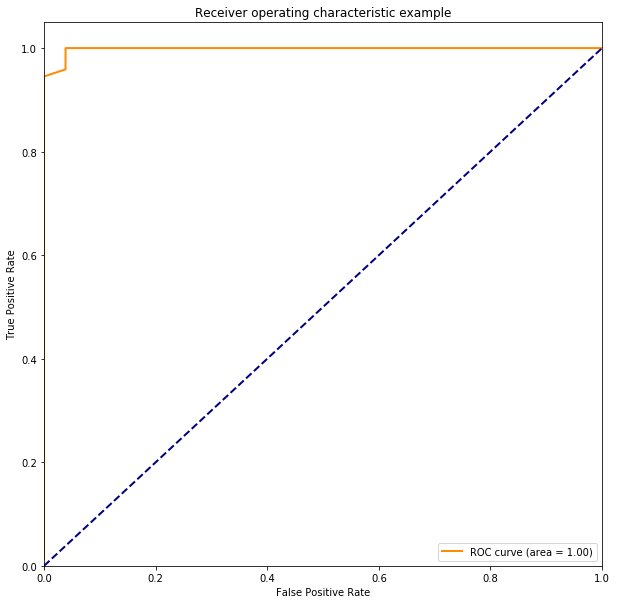

```python
y_pred = svm.predict_proba(X_test)[:, 1]
fpr, tpr, _ = roc_curve(y_test, y_pred)
roc_auc = auc(fpr, tpr)

plt.figure(figsize=(10,10))
lw = 2
plt.plot(fpr, tpr, color='darkorange',
         lw=lw, label='ROC curve (area = %0.2f)' % roc_auc)
plt.plot([0, 1], [0, 1], color='navy', lw=lw, linestyle='--')
plt.xlim([0.0, 1.0])
plt.ylim([0.0, 1.05])
plt.xlabel('False Positive Rate')
plt.ylabel('True Positive Rate')
plt.title('Receiver operating characteristic example')
plt.legend(loc="lower right")
plt.show()
```

# Conclusion

```
                                  *****************
                                  Name = GNB - 1#Approach - PhotoVilla
                                  Accuracy = 0.949685534591195
                                  Training Time = 4.280512094497681
                                  Test Time = 8.437445640563965
                                  *****************
                                  Name = Linear SVM - 1#Approach - PhotoVilla
                                  Accuracy = 0.9433962264150944
                                  Training Time = 169.62561988830566
                                  Test Time = 53.58669948577881
                                  *****************
                                  Name = GNB - 1#Approach - PhotoUfficio
                                  Accuracy = 0.8080808080808081
                                  Log Loss = 6.318068852727564
                                  Training Time = 2.920057773590088
                                  Test Time = 5.805481910705566
                                  *****************
                                  Name = Linear SVM - 1#Approach - PhotoUfficio
                                  Accuracy = 0.9090909090909091
                                  Log Loss = 0.13265681483572453
                                  Training Time = 89.46020197868347
                                  Test Time = 31.01409602165222
                                  *****************
                                  Name = GNB - 2#Approach - PhotoVilla
                                  Accuracy = 0.949685534591195
                                  Log Loss = 1.0486156021225261
                                  Training Time = 0.00997304916381836
                                  Test Time = 0.021976232528686523
                                  *****************
                                  Name = Linear SVM - 2#Approach - PhotoVilla
                                  Accuracy = 0.9811320754716981
                                  Log Loss = 0.027058498046843543
                                  Training Time = 0.06582331657409668
                                  Test Time = 0.020943880081176758
                                  *****************
                                  Name = GNB - 2#Approach - PhotoUfficio
                                  Accuracy = 0.7676767676767676
                                  Log Loss = 7.287524456993407
                                  Training Time = 0.003988504409790039
                                  Test Time = 0.009974479675292969
                                  *****************
                                  Name = Linear SVM - 2#Approach - PhotoUfficio
                                  Accuracy = 0.9191919191919192
                                  Log Loss = 0.15699700573329337
                                  Training Time = 0.07280588150024414
                                  Test Time = 0.022108793258666992
```

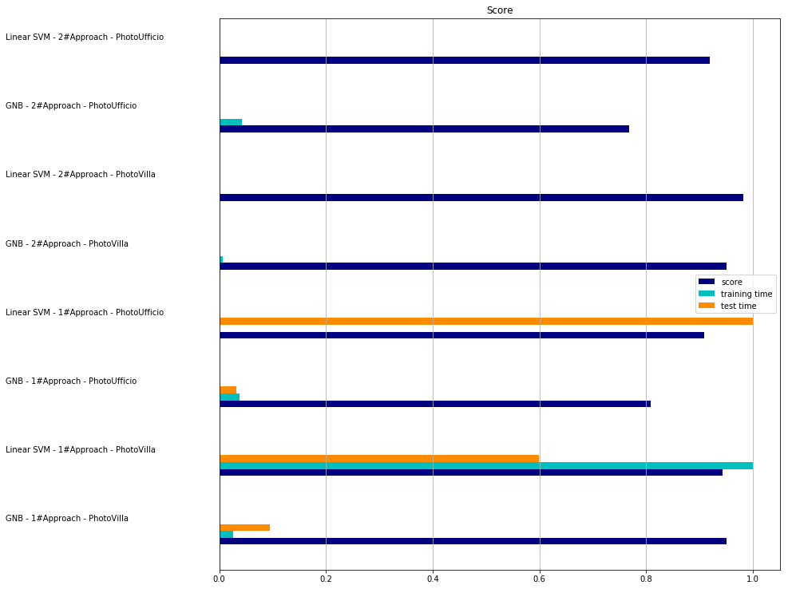

```
Total time spent in classification: 2.8411557117648707
Best accuracy: 0.9811320754716981
```

```python
displayScores()
```

After the SVM classifier, we can also note that the Second Approach (**Color Histogram Representation**) is more suitable to SVM that the 1# (**Whole image**): that's probably becouse SVM is a rigid classifier and suffer of *Overfitting* and *bias error* (incapability of adapting on a real case problem) and digest a more general and less adaptive representation as histogram balance this behavior.

Linear SVM on Histogram have wonderful results also on Photo_ufficio: it show the robustness of the classifier at the problem even if the domain problem change (from wineyard pictures to office and other contexts images). The little decrement on accuracy depends on the fact that the PhotoUfficio dataset have a lot of different subjects compared to PhotoVilla, but this do not affect the classifier too much.

# WHAT DO NOT WORK:

```python
# from sklearn.model_selection import StratifiedShuffleSplit
# from sklearn.model_selection import GridSearchCV

# def cross_validation(clf, clf_params,X,y):
#     start = time.time()
#     best_clf = GridSearchCV(estimator=clf,param_grid=clf_params, cv=5,scoring=None, return_train_score=True)
#     best_clf.fit(X,y)
#     end = time.time()
#     print("Accuracy for result of cross validation:",best_clf.best_score_)
#     print("Cross validation requires:",end-start,"sec")
#     return best_clf.best_estimator_
```

```python
# from sklearn import svm

# C_range = [10**(-1),10**(0),10**(1)]
# linear_svm_params = dict(C=C_range)
# linear_svm = svm.SVC(kernel="linear")
# best_linear_svm = cross_validation(linear_svm,clf_params=linear_svm_params,X=X_train,y=y_train)
```

In a learning curve, the performance of a model both on the training and validation set is plotted as a function of the training set size.

**Learning curves** further allow to easily illustrate the concept of (statistical) bias and variance.

**Bias** in this context refers to erroneous (e.g. simplifying) model assumptions, which can cause the model to *underfit* the data, cause by approximation of a real-life problem. A high-bias model does not adequately capture the structure present in the data.

**Variance** on the other hand quantifies how much the model varies as we change the training data. A high-variance model is very sensitive to small fluctuations in the training data, which can cause the model to overfit.

The amount of bias and variance can be estimated using **learning curves**:

- A model exhibits **high variance, but low bias** if the training score plateaus at a high level while the validation score at a low level, i.e., if there is a large gap between training and validation score.
- A model with **low variance but high bias**, in contrast, is a model where both training and validation score are low, but similar. Very simple models are high-bias, low-variance while with increasing model complexity they become low-bias, high-variance.

```python
import numpy as np
import matplotlib.pyplot as plt
from sklearn.naive_bayes import GaussianNB
from sklearn.svm import SVC
from sklearn.datasets import load_digits
from sklearn.model_selection import learning_curve
from sklearn.model_selection import ShuffleSplit

def plot_learning_curve(estimator, title, X, y, ylim=None, cv=None,
                        n_jobs=None, train_sizes=np.linspace(.01, 1.0, 50)):

    plt.figure(figsize=(15,7))
    plt.title(title)
    if ylim is not None:
        plt.ylim(*ylim)
    plt.xlabel("Training examples")
    plt.ylabel("Score")
    train_sizes, train_scores, test_scores = learning_curve(
        estimator, X, y, cv=cv, n_jobs=n_jobs, train_sizes=train_sizes)
    train_scores_mean = np.mean(train_scores, axis=1)
    train_scores_std = np.std(train_scores, axis=1)
    test_scores_mean = np.mean(test_scores, axis=1)
    test_scores_std = np.std(test_scores, axis=1)
    plt.grid()

    plt.fill_between(train_sizes, train_scores_mean - train_scores_std,
                     train_scores_mean + train_scores_std, alpha=0.1,
                     color="r")
    plt.fill_between(train_sizes, test_scores_mean - test_scores_std,
                     test_scores_mean + test_scores_std, alpha=0.1, color="g")
    plt.plot(train_sizes, train_scores_mean, 'o-', color="r",
             label="Training score")
    plt.plot(train_sizes, test_scores_mean, 'o-', color="g",
             label="Cross-validation score")

    plt.legend(loc="best")
    return plt
```

```python
#plot_learning_curve(gnb, "Learning Curve of the GaussianNB", X_train, y_train, cv=5)
#plt.show()
```

```python
# from sklearn import svm

# linear_svm = svm.SVC(kernel="linear",probability=True)
# linear_svm.fit(X_train,y_train)
# original_svm_acc=linear_svm.score(X_test,y_test)
# print("SCORE:",original_svm_acc)
```